[figure not shown]

[figure not shown]

[figure not shown]

# Descriptieve analyse

### van de ingaven is clientgebonden

99%

### **Ingaven per leefgroep tabel**

| variabele | ADB | HEI1 | HEI2 | HEI3 | HEI4 | HEI5 | HEI6 | HEI7 | HEI8 | HG | ME1 | ME2 | NACH | S123 | S456 | SABC | ST1 | ST2 | ST3 | TD | VLO | WA1 | WA2 | WA34 | WA5 | WA6 |
| --- | --- | --- | --- | --- | --- | --- | --- | --- | --- | --- | --- | --- | --- | --- | --- | --- | --- | --- | --- | --- | --- | --- | --- | --- | --- | --- |
| aantal_ingaven | 3 | 748 | 629 | 1098 | 479 | 794 | 935 | 920 | 955 | 1 | 1044 | 310 | 3 | 1257 | 997 | 1 | 747 | 484 | 588 | 1 | 1 | 696 | 418 | 1163 | 678 | 367 |
| op_naam (%) | 1 (33%) | 746 (100%) | 626 (100%) | 1094 (100%) | 477 (100%) | 791 (100%) | 934 (100%) | 920 (100%) | 952 (100%) | 1 (100%) | 1044 (100%) | 294 (95%) | 0 (0%) | 1242 (99%) | 979 (98%) | 0 (0%) | 747 (100%) | 482 (100%) | 588 (100%) | 0 (0%) | 1 (100%) | 693 (100%) | 413 (99%) | 1156 (99%) | 677 (100%) | 358 (98%) |
| niet_op_naam (%) | 2 (67%) | 2 (0%) | 3 (0%) | 4 (0%) | 2 (0%) | 3 (0%) | 1 (0%) | 0 (0%) | 3 (0%) | 0 (0%) | 0 (0%) | 16 (5%) | 3 (100%) | 15 (1%) | 18 (2%) | 1 (100%) | 0 (0%) | 2 (0%) | 0 (0%) | 1 (100%) | 0 (0%) | 3 (0%) | 5 (1%) | 7 (1%) | 1 (0%) | 9 (2%) |

### **Ingaven per leefgroep grafiek**

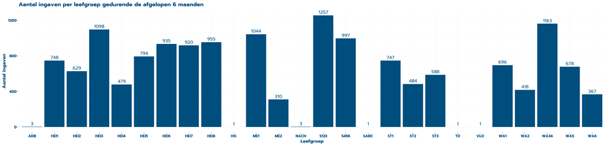

### **Ingaven per dag grafiek**

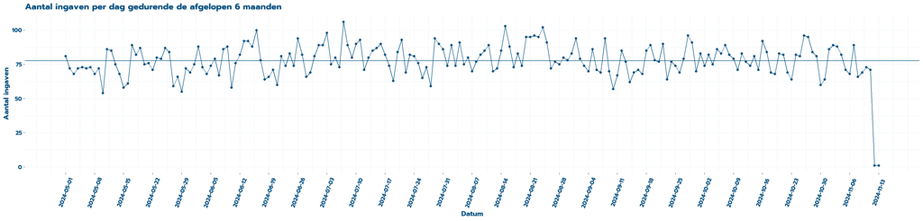

### **Ingaven per week grafiek**

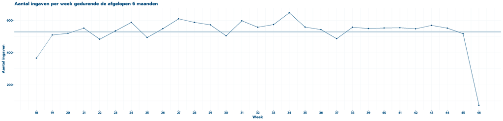

# Vragen

### **Welke data levert momenteel al inzichten over de situatie ‘as is’?**

- Welke leefgroepen het logboek gebruiken tijdens de nacht
- Hoeveel ingaven er zijn per leefgroep
- Hoeveel ingaven verbonden zijn aan een client
- Hoeveel ingaven er zijn per dag, week, maand, …
- Hoeveel ingaven er zijn per client en deze eventueel linken met de zorgzwaarte (B en P waarden vanuit IDO of zorggebruikers)

### **Welke data zouden we zinvol vinden maar is niet te extraheren uit de huidige opslag?**

- Niet iedere ingave is aan een client verbonden
  - Moeilijk om hier een alarm aan te koppelen
- Enkel datum van ingave wordt bijgehehouden
  - Moeilijk om hier een alarm aan te koppelen
  - Niet geweten welke ingave tijdens welke nacht gebeurde (bv ingave op 4 november kan in de nacht van 3-4 november of 4-5 november zijn, waardoor we alarmen van 3, 4 en 5 november moeten nakijken)
- Geen duidelijk overzicht welke ingaven betrekking hebben tot welke onderwerpen
  - Moeilijk om deze te linken aan alarmen

### **Welke datastructuren hebben we nodig om analyses over nachtzorg te kunnen maken? en Welke data moeten we verzamelen bij het opzetten van een pilootstudie met Kepler Night Nurse?**

- Datum **en tijdstip** van ingave
- Verplichte ingave van een **clientnummer**
- Tag die verbonden wordt met een ingave om aan te duiden **wat voor observatie** dit was (alarm, ronde, …)
- Er is veel ruimte voor human error, bv SABC (dagcentrum) en TD (technische dienst) hebben een ingave